# 08_review_03

LJH

2022-08-10

## **확률변수와 확률분포**

#### **확률변수**

확률적으로 서로 다른 값을 가질 수 있는 어떤 변수  
**- 이산확률변수**  
확률변수 X가 취할 수 있는 값이 불연속일 때  
**- 연속확률변수**  
확률변수 X가 취할 수 있는 값이 연속일 때

#### **확률분포**

확률변수 X가 갖느 값과 X가 이 값을 가질 확률 사이의 대응 관계(함수)  
**이산확률분포**  
이산확률변수에 대한 확률질량함수(PM(Mass)F)  
**연속확률분포**  
연속확률변수에 대한 확률밀도함수(PD(Density)F)

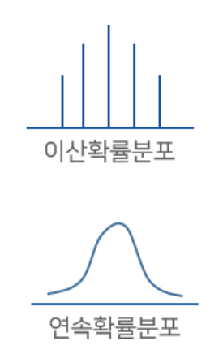

#### **정규분포**

확률밀도함수를 그래프로 그렸을 때 종형 곡선이 나타나는 확률분포  
*N(m, o^2)* : 평균이 m 표준편차가 o인 정규분포

#### **표준정규분포**

*N(0, 1)* : 평균이 0 , 표준편차가 1인 정규분포

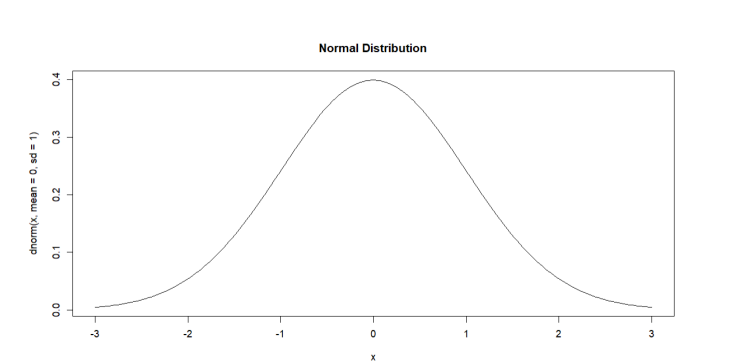

#### **정규분포의 유용성**

다양한 사회 현상, 자연 현상에 대한 우리의 직관과 부합하는 특성을 가짐

#### **정규분포의 특성**

**- 기댓값**  
데이터의 분포를 숫자 하나로 요약할 수 있음  
**- 표준편차**  
: 평균에서 자료가 떨어져 있는지를 나타내는  
- 표준편차가 클수록 그래프는 작고 납작해짐  
- 표준편차가 작을수록 그래프는 높고 뾰족해짐

#### **pnorm함수(누적분포함수)**

정규분포의 평균과 표준편차를 알고있을 때 q값이 정규분포 안에 있을 확률을 알고 싶을 때  
pnorm(q, mean, sd)  
- q : 찾고싶은 값  
- mean : 평균 값  
- sd : 표준편차

- q_1과 q_2 사이에 있을 확률을 구하고 싶을 때(q_1 > q_2)  
  pnorm(q_1, mean, sd) - pnorm(q_2, mean, sd)
- q_2보다 작을 확률  
  pnorm(q_2, mean, sd)
- q_1보다 클 확률  
  1 - pnorm(q_1, mean, sd)

###### plot 함수에서 특정 부분을 색칠할 수 있는 함수

#### **표준화(정규화)**

정규분포를 따르는 확률변수 X를 표준정규분포를 따르는 확률변수 Z로 변환  
*X~N(m,o^2) -> Z = (X-m)/o, Z~N(0,1)  
**표준화를 하는 이유**  
평균과 표준편차가 다른 정규분포를 따르는 두 변수의 값을 비교하는 경우

#### **dnorm함수(확률밀도함수)**

dnorm(q, mean, sd)  
- x : 찾고싶은 값  
- mean : 평균 값  
- sd : 표준편차

#### **dnorm함수(확률밀도함수)**

dnorm(q, mean, sd)  
- x : 찾고싶은 값  
- mean : 평균 값  
- sd : 표준편차

#### **이항 분포**

어떤 시행에서 사건이 일어날 확률이 𝑝인 독립시행을 𝑛회 반복할 때  
사건이 일어나는 횟수인 확률변수 𝑋는 이항분포 𝐵(𝑛, 𝑝)를 따른다.  
*- 𝑋~𝐵(𝑛, 𝑝)*

###### plot 함수에서 add = T를 적으면 앞의 plot에 추가되어 나타난다.

###### set.seed(n)함수를 통해서 변수 결과를 n으로 고정시킨다.

### **확률분포 관련 R 함수**

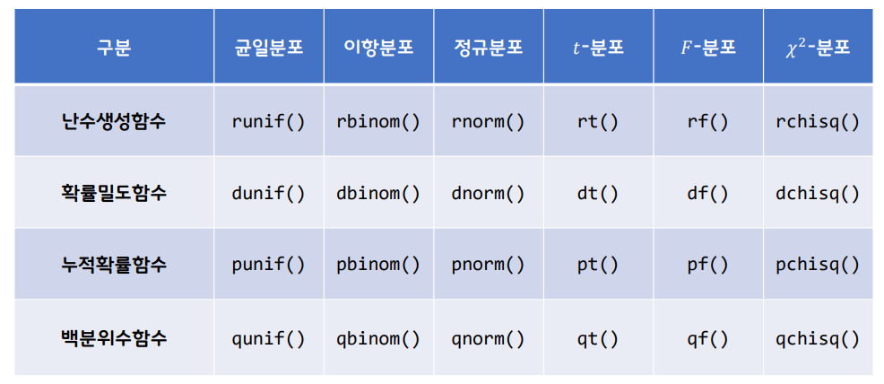

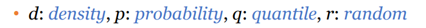

random : 난수 / density : 확률 / probability : 누적 / quantile: 백분위

- **균일분포** : 특정 범위 내에서 균등하게 나타나는 확률을 가지는 확률분포  
- **이항분포** : 임의의 시행 결과가 성공 또는 실패 중 하나인 시행  
- **정규분포** : 자연현상 또는 사회현상에서 자주 관찰되는 종 모양의 확률분포  
- **표준 정규분포** : 평균이 0이고 표준편차가 1인 정규분포

### **정규분포를 따르는 확률변수의 값은 𝜇 ± 1.96 × 𝜎 범위 안에 있을 확률이 약 95%이다.**

#### **모집단과 표본집단**

- 모집단 : 전체집단
- 표본집단 : 모집단에서 추출한 부분 집합

#### **sample함수**

sample(x, size)  
x : 모집단  
size : 샘플링 횟수  
replace : True(복원추출)

#### **중심극한정리**

**표본의 크기가 충분히 클 때(n ≥ 30)**  
표본분포는 모집단의 분포와 상관없이 정규분포를 따른다.